# segmentation of customer - Kmeans

Data: The dataset has future merchant transaction activity, up to 1 year for each merchant.

### Question:

- How would you propose segmenting these users in ways that can be useful for Sales, Product, and other teams?  
  KMeans Clustering Algorithm
- In particular, how would you identify and predict high growth merchants?  
  Predictive model based on clusters

#### 1. Data Process

```python
import pandas as pd
from pandas import DataFrame
import numpy as np
from datetime import datetime
import dateutil.parser

case = pd.read_csv('/Users/ranwei/Desktop/case_final.csv')
case.isnull().sum() #there is no missing value
print "Number of different users are: " + str(len(set(case.user)))
print "Total number of observations: " + str(len(case.user))
```

```
Number of different users are: 8402
Total number of observations: 1524710
```

##### Convert ISO 8601 date elements to 4 cells: Year, Month, Day and Hour

```python
case['Year'] = case['time'].apply(lambda x: dateutil.parser.parse(x).year)
case['Month'] = case['time'].apply(lambda x: dateutil.parser.parse(x).month)
case['Day'] = case['time'].apply(lambda x: dateutil.parser.parse(x).day)
case['Hour'] = case['time'].apply(lambda x: dateutil.parser.parse(x).hour)

newcase = case[['user', 'amount_in_cents', 'Year', 'Month', 'Day', 'Hour']]
```

#### 2. Segmentation

Q: How would you propose segmenting these users in ways that can be useful for Sales, Product, and other teams? - I used K-Means clustering algorithm to segment users based on features described below.

Our target is to segment our users for future analysis, so that we need to find a method to distinguish them.

I chose to user K-means clustering algorithm to segment the user based on features generated below. K-means works by grouping the points together in such a way that the distance between all the points and the midpoint of the cluster they belong to is minimized. Thus, K-means algorithm would help us to learn the user’ behaviors based on total sales, increases between years, active during seasons, and others.

First, I created the “season” features: Spring, Summer, Autumn, and Winter. To group by “newcase” dataset based on both “user” and “Month” and then to compute the occurrences under different months will give us the occurrences of those 4 seasons. The dataframe named “data1” contained columns: User, Sum (amount in total), Mean, Count (number of transaction), High (the highest amount_in_cents), Duration (how many years user user Stripe), Spring (occurrences), Summer, Autumn and Winter.

Then, I created the “insightYear” dataframe. The main feature I would like to introduce here is the “Increase_btw_years”, which demonstrates the increase amounts between the total amount of parried different years. For example, if one user only has transaction in one year, the “Increase_btw_years” does not change and holds 0 value.

Finally, I merged “data1” and “insightYear” two dataframes together based on the same User ID. I used this merged dataframe also named “data1” in following process.

```python
# Create a SalesTotal dataframe contained summary of sales based on each user
f1 = {'Year': ['min', 'max'], 'amount_in_cents':['sum','mean', 'count','max']}
SalesTotal = newcase.groupby('user')['Year', 'amount_in_cents'].agg(f1).reset_index()
SalesTotal.columns = ['User', 'Sum', 'Mean', 'Count', 'High', 'Before', 'After']
SalesTotal['Duration'] = (SalesTotal.After - SalesTotal.Before) + 1

# Create a month dataframe contained each month and its occurrence of per user
month = newcase.groupby(['user', 'Month'])['Month'].size().reset_index()
month.columns = ['User', 'Month', 'Occurrence']

# User pivot to transpose the previous month dataframe
result = month.pivot(index='User', columns='Month', values='Occurrence')
result.columns = ['Month{:d}'.format(col) for col in result.columns]
result = result.reset_index()
```

```python
#Create a new dataframe contained features
title = ['User', 'Sum', 'Mean', 'Count', 'High', 'Before', 'After', 'Duration', 'Month1', 'Month2', 'Month3',
         'Month4', 'Month5', 'Month6','Month7', 'Month8', 'Month9','Month10', 'Month11', 'Month12']

datasample = pd.DataFrame(index=range(0, len(SalesTotal)),columns = title)
datasample = datasample.fillna(SalesTotal)
data1 = datasample.fillna(result)
data1 = data1.fillna(0)

#Seaonal features
data1['Spring'] = data1['Month1'] + data1['Month2'] + data1['Month3']
data1['Summer'] = data1['Month4'] + data1['Month5'] + data1['Month6']
data1['Autumn'] = data1['Month7'] + data1['Month8'] + data1['Month9']
data1['Winter'] = data1['Month10'] + data1['Month11'] + data1['Month12']

data1 = data1[['User', 'Sum', 'Mean', 'Count', 'High','Duration','Spring','Summer','Autumn','Winter']]
```

```python
# Create a YearSale dataframe contained the column 'YearSales', which indicates the total amount of per year
insightsample = newcase.groupby(['user', 'Year'])['amount_in_cents'].sum().reset_index()
# insight.groupby(['user', 'Year'])['amount_in_cents'].diff()
insightsample.columns = ['User', 'Year', 'YearSales']

# Add 'Increase_btw_Years' column to demonstrate the increase amounts between different year according to different user
# if 'Increase_btw_Years' equals to 0, we found that the user is only being active one year
insight['Increase_btw_Years'] = insight['YearSales'].diff()
mask = insight.User != insight.User.shift(1)
insight['Increase_btw_Years'][mask] = 0

# Finally, generate the dataframe 'insighYear' with only two columns: User, Increase_btw_Year
insightYear = insight.groupby(['User'])['Increase_btw_Years'].sum().reset_index()
data1 = data1.merge(insightYear)
data1.head()
```

|  | User | Sum | Mean | Count | High | Duration | Spring | Summer | Autumn | Winter | Increase_btw_Years |
| --- | --- | --- | --- | --- | --- | --- | --- | --- | --- | --- | --- |
| 0 | 00038f0484334ac047449166cfbbf6452b31c85c | 979323 | 3159.106452 | 310 | 24052 | 1 | 105.0 | 205.0 | 0.0 | 0.0 | 0.0 |
| 1 | 0012a74e2bb1ab0073b2e18532e87474b6b7cfca | 9140 | 4570.000000 | 2 | 5893 | 1 | 0.0 | 0.0 | 0.0 | 2.0 | 0.0 |
| 2 | 001855810c25d8bb03210f8c0114de27da9cd76c | 1506469 | 7725.482051 | 195 | 64580 | 2 | 72.0 | 106.0 | 0.0 | 17.0 | 1248155.0 |
| 3 | 001f3978fa7cad62f2e2ddfa155184a316282b0e | 2769384 | 16683.036145 | 166 | 78891 | 2 | 27.0 | 71.0 | 54.0 | 14.0 | 2733304.0 |
| 4 | 00317873b9dcbcff6759f7ec4225d8531520fdcb | 8058 | 4029.000000 | 2 | 5051 | 1 | 2.0 | 0.0 | 0.0 | 0.0 | 0.0 |

##### K-means clustering algorithm

Now in order to create the clusters, I used the KMeans functionality from scikit-learn, and chose 10 clusters here.

After applying K-means algorithm, we could easily see the number of users under different clusters. We could find groups of users that mean the users in a group will be similar (or related) to one another and different from (or unrelated to) the users in other groups.

Here, I chose the cluster0 to interpret one of those clusters, because the cluster0 contains the most of users, 8154 numbers of users. Also, even though several clusters only contained a few value, we may find more users in those clusters if we have a very large dataset. Or, we could conclude that those clusters may not be significant for further analysis, and thus, we would like to only focus on “informative” clusters with quite large number of users.

The center centroid (cluster center) of cluster0 is a high-dimension vector: Sum(680671), Mean(23373), Count(66), High(72283), Duration(2), Spring(16), Summer(16), Autumn(18), Winter(0), and Increase_btw_Years(17453). Thus, for users in cluster0, they have similar features compared among others, and similar values compared with cluster center. They gather around the cluster0 center.

I would like to then apply supervise learning method on different clusters in order to build predictive model.

```
   User
0  8154
1     2
2     3
3     1
4    26
5     6
6     4
7    14
8   190
9     2
```

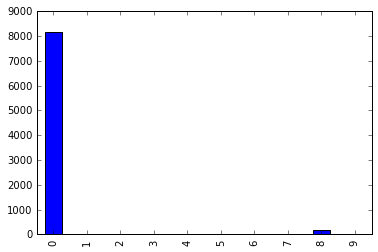

```python
from sklearn.cluster import KMeans
from ggplot import *
np.random.seed(1)

mat = data1.ix[:,1:].as_matrix()
#print mat;

km = KMeans(n_clusters=10)
km.fit(mat) #Compute k-means clustering
labels = km.labels_

center = km.cluster_centers_

data1['labels'] = labels
cluster = data1.groupby('labels').count().reset_index()
cluster = cluster.ix[:, 1:2]
print cluster

cluster['User'].plot.bar()
```

```python
# Extract cluster 0 and cluster 8 for future analysis, you can also extract all of them. Here, I just extract the most
# important two

data2 = data1.copy()

# Set seasonal features to 1 if customer has action during that season
data2.loc[data2.Spring != 0.0, 'Spring'] = 1
data2.loc[data2.Summer != 0.0, 'Summer'] = 1
data2.loc[data2.Autumn != 0.0, 'Autumn'] = 1
data2.loc[data2.Winter != 0.0, 'Winter'] = 1

# We would like to set features in Season to categorical features
Season = ['Duration', 'Spring','Summer','Autumn','Winter']
for i in range(0, len(Season)):
    data2[Season[i]] = data2[Season[i]].astype('category')

cluster0 = data2.loc[data1['labels'] == 0]
cluster8= data2.loc[data1['labels'] == 8]
```

#### 3. Prediction

Q: In particular, how would you identify and predict high growth merchants? - Based on different cluster, I applied supervised learning algorithm on selected cluster, cluster0. I extracted two important cluster here, cluster0 (8154) and cluster8(190) for the predictive model. Since we would like to identify and predict the high growth merchants. Before apporching predictive model, I convered “Duration” to categorical data.

##### Cluster0 Prediction

To interpret the model:

##### Cluster8 Prediction

```
                               OLS Regression Results
===================================================================================
Dep. Variable:     scipy.special.cbrt(Sum)   R-squared:                       0.215
Model:                                 OLS   Adj. R-squared:                  0.215
Method:                      Least Squares   F-statistic:                     1117.
Date:                     Sun, 20 Mar 2016   Prob (F-statistic):               0.00
Time:                             10:39:37   Log-Likelihood:                -41737.
No. Observations:                     8154   AIC:                         8.348e+04
Df Residuals:                         8151   BIC:                         8.350e+04
Df Model:                                2
Covariance Type:                 nonrobust
======================================================================================
                         coef    std err          t      P>|t|      [95.0% Conf. Int.]
--------------------------------------------------------------------------------------
Intercept             40.4382      0.584     69.184      0.000        39.292    41.584
Duration[T.2]         42.7910      0.910     47.033      0.000        41.008    44.574
Increase_btw_Years  1.696e-06   4.75e-07      3.573      0.000      7.65e-07  2.63e-06
==============================================================================
Omnibus:                     1618.840   Durbin-Watson:                   2.021
Prob(Omnibus):                  0.000   Jarque-Bera (JB):             2997.935
Skew:                           1.238   Prob(JB):                         0.00
Kurtosis:                       4.640   Cond. No.                     2.11e+06
==============================================================================

Warnings:
[1] Standard Errors assume that the covariance matrix of the errors is correctly specified.
[2] The condition number is large, 2.11e+06. This might indicate that there are
strong multicollinearity or other numerical problems.
```

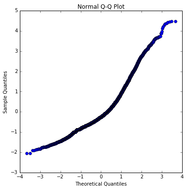

```python
import statsmodels.api as sm
from statsmodels.formula.api import ols
import matplotlib.pyplot as plt
import scipy

%matplotlib inline
# Cluster 0:
fit0 = ols(formula = "scipy.special.cbrt(Sum) ~ Increase_btw_Years + Duration", data = cluster0).fit()

print fit0.summary()

# Normality
fit0_fit = fit0.fittedvalues
fit0_resid = fit0.resid_pearson
fig, ax = plt.subplots(figsize=(6,6))
fig = sm.qqplot(fit0_resid, ax = ax)
plt.title('Normal Q-Q Plot')
```

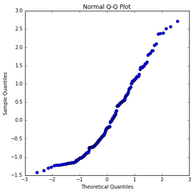

```python
# Cluster 8:
fit8 = ols(formula = "scipy.special.cbrt(Sum) ~ Increase_btw_Years + Duration", data = cluster8).fit()

# Normality
fit8_fit = fit8.fittedvalues
fit8_resid = fit8.resid_pearson
fig, ax = plt.subplots(figsize=(6,6))
fig = sm.qqplot(fit8_resid, ax = ax)
plt.title('Normal Q-Q Plot')
```

#### 4. Model Selection (Evaluation) - Cross Validation

```python
from sklearn import linear_model
from sklearn import preprocessing
from sklearn import cross_validation

Y = data1.ix[:, 1:2]
Y = scipy.special.cbrt(Y)
Y = np.array(Y)

pred_X1 = data1[['Increase_btw_Years', 'Duration']]
pred_X1 = np.matrix(pred_X1)

#fit2
fit2 = linear_model.LinearRegression()
fit2.fit(pred_X1, Y)

scores2 = cross_validation.cross_val_score(fit2, pred_X1, Y, cv = 10, scoring = 'mean_squared_error')
print "Q1 model, minimal MSE through 10-fold CV is: %5f" % abs(min(scores2))

#fit3
pred_X2 = data1[['Increase_btw_Years', 'Duration', 'Spring', 'Summer', 'Autumn', 'Winter']]
pred_X2 = np.matrix(pred_X2)

fit3 = linear_model.LinearRegression()
fit3.fit(pred_X2, Y)

scores3 = cross_validation.cross_val_score(fit3, pred_X2, Y, cv = 10, scoring = 'mean_squared_error')
print "Q2 model, minimal MSE through 10-fold CV is: %5f" % abs(min(scores3))
```

```
Q1 model, minimal MSE through 10-fold CV is: 4351.109158
Q2 model, minimal MSE through 10-fold CV is: 5334.486599
```

#### 5. Discussion

For the further studies, we can also generate more features based on Hours and other original data from case_final dataset. We can also combine those features to find the interaction between them in order to better segment users.

There are also many classic segmentation methods. For example, we can compute the users' sales in different months of per year.

First of all, I think it could work to partition the data for each merchant into two parts (training and testing), obviously the training has to be the earlier time periods data and the testing later time periods. For example, we can take data from 1st charge up until 365*80% days later as training and the remaining as testing.

I can imagine, for some merchants, this may result in very few observations in either or both part, some more refined way of partitioning might be necessary then.

An alternative is to partition the data into training and testing with merchant as units, but that would propose some difficulties too, since matching up two merchants is nearly impossible.

In summary, one should think carefully about how to partition the data, since it’s difficult to say anything reliable without a testing step.

If we want to apply Kmeans directly, these packages might be helpful https://www.jstatsoft.org/article/view/v065i04/v65i04.pdf. For example, time point and amount of money for every merchant create a joint trajectory, so it seems straightforward to cluster these joint trajectories with kml3d. If we want to perform feature engineering instead of using raw data, it’s probably better to consult someone with better domain knowledge.